# What is cooperative housing?

Gatlin Johnson

La Reunion Cooperative

# Well, what is cooperation?

Dictionaries lend some insight:

- Working with others toward the same end
- Assisting others
- A common effort

# Working with others toward the same end

# Assisting others

# A Common Effort

# Cooperation is that, as an economic strategy

- We all have some shared basic needs
  - Food
  - Shelter
  - Wifi (?)
- Some of us have more complex needs as well
  - Physical
  - Financial
  - Emotional
- And yet all too often problems go unsolved; needs aren't met.
  - *Even though these problems aren't moon-shots!*

# How do tractable problems go unsolved?

- **Governance**
  - Many people have limited or no voice in decisions affecting them
- **Economic participation**
  - Renting one's life does not encourage stewardship (or allow it, in some cases).
- **Division**
  - Organizing is difficult and laborious on top of other responsibilities.
  - How do you know anyone will join?

# Cooperation is a model for collective empowerment

Skip the "if you can't beat 'em" part and **just join 'em!**

- Democratic member control
- Member economic participation
- Voluntary and open membership

# Cooperative housing puts the **YOU** in "US"

Cooperative housing is housing centered around these principles.

- Members meet and make decisions democratically
- Members pay dues and volunteer
  - Collective ownership of profits
  - Lowered costs: don't pay someone else to sweep!
  - Encourages a sense of community and equality
- The community is inclusive and welcomes all who want to participate

*Sorry for the pun.*

# History

- Rochdale Society of Equitable Pioneers, 1844
- College cooperatives
  - ICC Ann Arbor, 1937
  - NASCO, 1968
- Meanwhile, in Texas ...
  - ICC Austin, 1930s
  - College Houses, 1960s
  - CHEA -- *that's us!*

# Rochdale Principles

The themes of this presentation are part of a larger code, defined by the International Co-operative Alliance:

- Voluntary and Open Membership
- Democratic Member Control
- Member Economic Participation
- Autonomy and Independence
- Education, Training, and Information
  - Hey, that's what I'm doing here!
- Cooperation Among Cooperatives
- Concern for Community

# Enough waxing philosophic, how does this work?

Case study: La Reunion Cooperative and CHEA

- Founded in 2013 by volunteers
  - Most lived in coops before
  - Part of larger organization, CHEA
- Purchased with help from NASCO Properties (NP)
  - Sister organization to NASCO which develops and assists cooperatives.
  - CHEA itself elects a member to the NP board. Rochdale #6.
- Residents meet once a week to
  - Decide policy
  - Approve financial decisions
  - Review members
  - Eat dinner and talk together!

But La Reunion is just the house.

# Enough waxing philosophic, how does this work? (cont'd)

Community Housing Expansion of Austin (CHEA)

- Founded in 2002 by former college coopers
- First house, Sasona, bought in south Austin
- Joined NP after meeting financial difficulties
- Each house elects two representatives to the Board.
  - A fifth community representative is elected by the general membership at a special meeting.
  - CHEA also generally elects a representative to the NP board.
- Board is tasked with ensuring the legal and financial stability of CHEA and defers most responsibilities to the houses.

# And *does* it work?

Cooperation works!

- Rent is extremely low at both houses relative to surrounding market.
- Both houses are independently financially solvent.
- Houses are empowered to take care of themselves, and **they do.**
  - No assembly of more than 1 person is ever going to be harmonious 24/7
  - Cooperation is about *how* we deal with problems.
- Coops exist around the country,
- Every year coopers meet in Ann Arbor, MI to discuss housing, social justice, and other topics of concern for communities.
- "No [person] is an island." - John Donne

# Who else does this?

These people across the country, for starters.

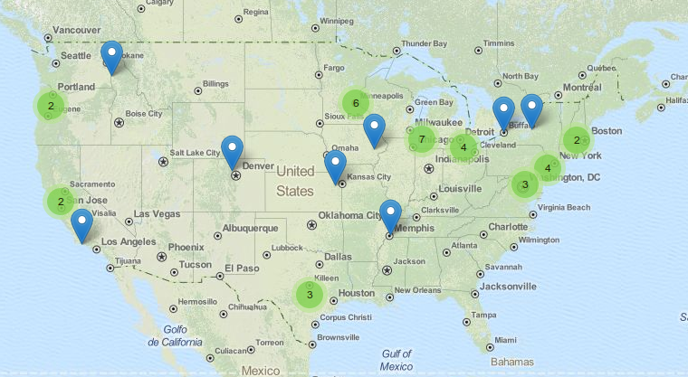

Map of NASCO coops

# Questions?

Feel free to contact me at `outreach@lareunioncoop.org`.

- La Reunion Website: http://lareunioncoop.org
- Sasona Website: http://sasona.org
- CHEA Website: http://chea.coop
- NASCO Website: http://nasco.coop